# Project1

Prediction Analysis Project 2020  
Supervisor Name: Eng. Mohammad Fathi – Wakeb Co.  
Group No. 1  
Project Description:  
This project is working on a store dataset that has pure data of five years ago. furthermore, this dataset contains the following data e.g.: (Number of branches, Sales, date of sale, items …etc.). The aims of this project are predicting store sales for the next three months to gets highly commercial benefits for this store by exploring different time series

## Day1: Explore and understand the dataset and its variables and do some cleaning and wrangling.

```python
#use the libraries to analysiz the dataset
import pandas as pd
import numpy as np
import matplotlib.pyplot as plt
import seaborn as sns

%matplotlib inline

import warnings
warnings.filterwarnings("ignore")
```

```python
#read the dataset
df = pd.read_csv('train.csv')
df.head()
```

|  | date | store | item | sales |
| --- | --- | --- | --- | --- |
| 0 | 2013-01-01 | 1 | 1 | 13 |
| 1 | 2013-01-02 | 1 | 1 | 11 |
| 2 | 2013-01-03 | 1 | 1 | 14 |
| 3 | 2013-01-04 | 1 | 1 | 13 |
| 4 | 2013-01-05 | 1 | 1 | 10 |

```python
df.tail()
```

|  | date | store | item | sales |
| --- | --- | --- | --- | --- |
| 912995 | 2017-12-27 | 10 | 50 | 63 |
| 912996 | 2017-12-28 | 10 | 50 | 59 |
| 912997 | 2017-12-29 | 10 | 50 | 74 |
| 912998 | 2017-12-30 | 10 | 50 | 62 |
| 912999 | 2017-12-31 | 10 | 50 | 82 |

```python
df.info()
```

```
<class 'pandas.core.frame.DataFrame'>
RangeIndex: 913000 entries, 0 to 912999
Data columns (total 4 columns):
 #   Column  Non-Null Count   Dtype
---  ------  --------------   -----
 0   date    913000 non-null  object
 1   store   913000 non-null  int64
 2   item    913000 non-null  int64
 3   sales   913000 non-null  int64
dtypes: int64(3), object(1)
memory usage: 27.9+ MB
```

Here we are converting the data type of "date" to DateTime then apply changes.

```python
df['date']=pd.to_datetime(df['date'])
```

```python
#Check if there are a missing values
missing_df_data  = pd.concat([df.isnull().sum()], axis=1, keys=["Total of missing data"])
missing_df_data
```

|  | Total of missing data |
| --- | --- |
| date | 0 |
| store | 0 |
| item | 0 |
| sales | 0 |

```python
#Check if there are a duplicated values
df.duplicated().sum()
```

```
0
```

```python
#The number of rows in each column
df.count()
```

```
date     913000
store    913000
item     913000
sales    913000
dtype: int64
```

```python
df.describe()
```

|  | store | item | sales |
| --- | --- | --- | --- |
| count | 913000.000000 | 913000.000000 | 913000.000000 |
| mean | 5.500000 | 25.500000 | 52.250287 |
| std | 2.872283 | 14.430878 | 28.801144 |
| min | 1.000000 | 1.000000 | 0.000000 |
| 25% | 3.000000 | 13.000000 | 30.000000 |
| 50% | 5.500000 | 25.500000 | 47.000000 |
| 75% | 8.000000 | 38.000000 | 70.000000 |
| max | 10.000000 | 50.000000 | 231.000000 |

## Day2: Visualize data and relationship between every variable.

### 1- The Store Branches:

The Pie chart below shows that all the stores are equales.

```python
store1=df[df['store']== 1]
store2=df[df['store']== 2]
store3=df[df['store']== 3]
store4=df[df['store']== 4]
store5=df[df['store']== 5]
```

```python
store6=df[df['store']== 6]
store7=df[df['store']== 7]
store8=df[df['store']== 8]
store9=df[df['store']== 9]
store10=df[df['store']== 10]
```

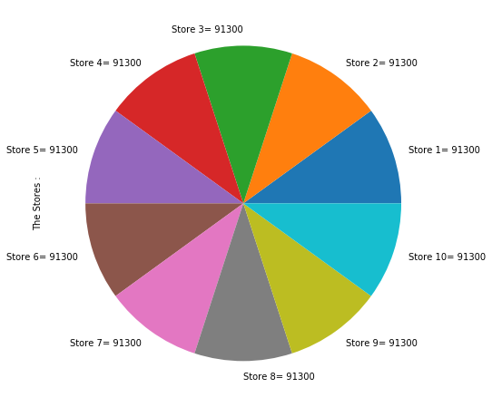

```python
s1='Store 1= '+str(len(store1))
s2='Store 2= '+str(len(store2))
s3='Store 3= '+str(len(store3))
s4='Store 4= '+str(len(store4))
s5='Store 5= '+str(len(store5))
s6='Store 6= '+str(len(store6))
s7='Store 7= '+str(len(store7))
s8='Store 8= '+str(len(store8))
s9='Store 9= '+str(len(store9))
s10='Store 10= '+str(len(store10))
snames = [s1,s2,s3,s4,s5,s6,s7,s8,s9,s10]
series = pd.Series([len(store1),len(store2),len(store3),len(store4),len(store5),len(store6),len(store7),len(store8),len(store9),len(store10)],
                   index=snames,
                   name='The Stores :')

series.plot.pie(figsize=(8, 8))
```

### 2- The Items :

The charts below show that all the "Items" are equals.

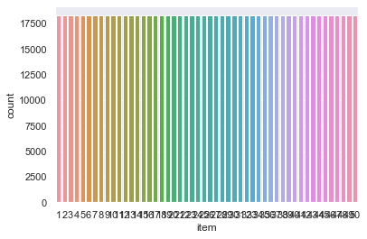

```python
sns.set(style="darkgrid")
ax = sns.countplot(x="item", data=df )
```

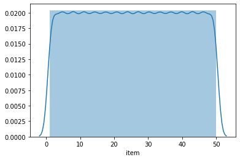

```python
sns.distplot(df['item'], bins=10, kde=True)
```

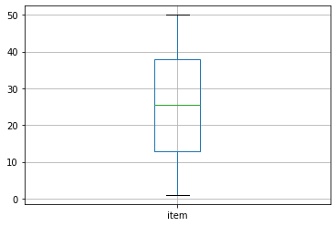

```python
df.boxplot(column='item')
```

```python
# Random number of item for test purpose(validation).
item1=df[df['item']== 1]
item49=df[df['item']== 49]
```

```python
len(item1)
```

```
18260
```

```python
len(item49)
```

```
18260
```

### 2- The Sales :

The next table is to show all the stores and their total of sales furthermore, a Bar chart.

```python
df2=df.groupby('store').sales.sum()
df2
```

```
store
1     4315603
2     6120128
3     5435144
4     5012639
5     3631016
6     3627670
7     3320009
8     5856169
9     5025976
10    5360158
Name: sales, dtype: int64
```

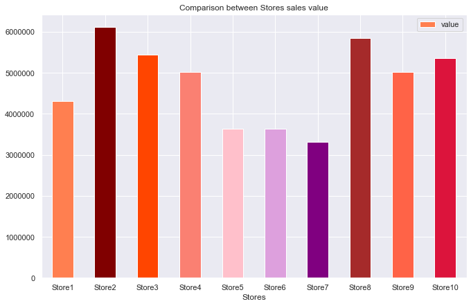

```python
df = pd.DataFrame({'Stores':[  'Store1','Store2', 'Store3','Store4','Store5','Store6','Store7','Store8','Store9','Store10' ],
                    'value':[store1.sales.sum(), store2.sales.sum(), store3.sales.sum(),store4.sales.sum(),store5.sales.sum(),store6.sales.sum(),store7.sales.sum(),store8.sales.sum(),store9.sales.sum(),store10.sales.sum()]})
df.plot.bar(x='Stores', y='value', rot=0 ,title="Comparison between Stores sales value",figsize=(11,7),color=['coral', 'maroon', 'orangered', 'salmon', 'pink','plum','purple','brown','tomato','crimson'] )
```

### 2- The Date :

For this part, we reread the dataset with adding the index as date.

```python
df1 = pd.read_csv('train.csv', parse_dates = ['date'], index_col= 'date')

df1['2015-02':'2015-02'].sales.mean()
```

```
39.37978571428572
```

```python
df1['2015-02':'2015-02']
```

| date | store | item | sales |
| --- | --- | --- | --- |
| 2015-02-01 | 1 | 1 | 17 |
| 2015-02-02 | 1 | 1 | 6 |
| 2015-02-03 | 1 | 1 | 10 |
| 2015-02-04 | 1 | 1 | 8 |
| 2015-02-05 | 1 | 1 | 18 |
| ... | ... | ... | ... |
| 2015-02-24 | 10 | 50 | 50 |
| 2015-02-25 | 10 | 50 | 50 |
| 2015-02-26 | 10 | 50 | 53 |
| 2015-02-27 | 10 | 50 | 63 |
| 2015-02-28 | 10 | 50 | 68 |

14000 rows × 3 columns

```python
df['month'] = df['date'].dt.strftime('%b')
df['year'] = df['date'].dt.year
df.tail()
```

|  | date | store | item | sales | month | year |
| --- | --- | --- | --- | --- | --- | --- |
| 912995 | 2017-12-27 | 10 | 50 | 63 | Dec | 2017 |
| 912996 | 2017-12-28 | 10 | 50 | 59 | Dec | 2017 |
| 912997 | 2017-12-29 | 10 | 50 | 74 | Dec | 2017 |
| 912998 | 2017-12-30 | 10 | 50 | 62 | Dec | 2017 |
| 912999 | 2017-12-31 | 10 | 50 | 82 | Dec | 2017 |

```python
year13=df.query("year == 2013")
year14=df.query("year == 2014")
year15=df.query("year == 2015")
year16=df.query("year == 2016")
year17=df.query("year == 2017")
```

```python
year15.tail()
```

|  | date | store | item | sales | month | year |
| --- | --- | --- | --- | --- | --- | --- |
| 912264 | 2015-12-27 | 10 | 50 | 57 | Dec | 2015 |
| 912265 | 2015-12-28 | 10 | 50 | 42 | Dec | 2015 |
| 912266 | 2015-12-29 | 10 | 50 | 45 | Dec | 2015 |
| 912267 | 2015-12-30 | 10 | 50 | 51 | Dec | 2015 |
| 912268 | 2015-12-31 | 10 | 50 | 44 | Dec | 2015 |

### 4- Sales VS Date

Classifying the sales depending on the months.

```python
dategroub = df.groupby(df['date'].dt.strftime('%B'))['sales'].sum().sort_values()
dategroub
```

```
date
January      2753149
February     2776177
December     3050808
March        3666182
October      3967520
September    4130457
April        4136467
November     4141356
August       4580655
May          4582437
June         4726911
July         5192393
Name: sales, dtype: int64
```

Rearrangement the months.

```python
dategroub1 = df.groupby(df['date'].dt.month)['sales'].sum()
dategroub1
```

```
date
1     2753149
2     2776177
3     3666182
4     4136467
5     4582437
6     4726911
7     5192393
8     4580655
9     4130457
10    3967520
11    4141356
12    3050808
Name: sales, dtype: int64
```

The chart below shows the peak of monthly sales.

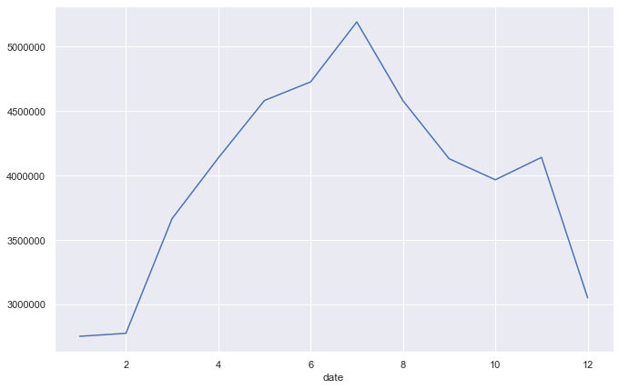

```python
dategroub1.plot(figsize=(11,7))
```

This diagram shows Sales Trends over the whole data in 5 years and separately over each year.

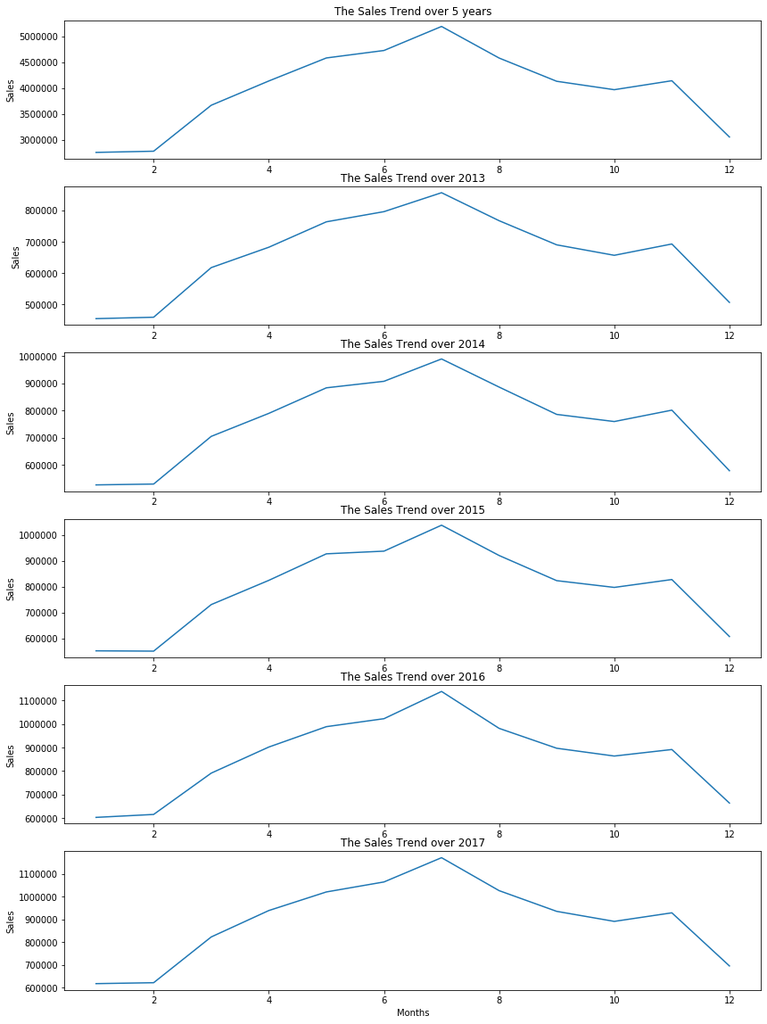

```python
fig, axs = plt.subplots(6,figsize=(14,20))


axs[0].plot(df.groupby(df['date'].dt.month)['sales'].sum())
axs[1].plot(year13.groupby(df['date'].dt.month)['sales'].sum())
axs[2].plot(year14.groupby(df['date'].dt.month)['sales'].sum())
axs[3].plot(year15.groupby(df['date'].dt.month)['sales'].sum())
axs[4].plot(year16.groupby(df['date'].dt.month)['sales'].sum())
axs[5].plot(year17.groupby(df['date'].dt.month)['sales'].sum())
axs[0].set_title('The Sales Trend over 5 years')
axs[1].set_title('The Sales Trend over 2013')
axs[2].set_title('The Sales Trend over 2014')
axs[3].set_title('The Sales Trend over 2015')
axs[4].set_title('The Sales Trend over 2016')
axs[5].set_title('The Sales Trend over 2017')
axs[5].set(xlabel='Months')
for ax in axs.flat:
    ax.set(ylabel='Sales')
```

This diagram shows the Sales pattern over the years.

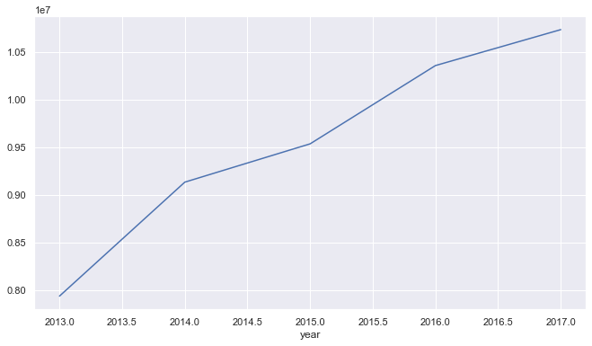

```python
dy.plot(figsize=(11,6))
```

### Identifying if there are outliers

In the next 6 diagrams below they are helping on identifying the outliers by using boxplot.

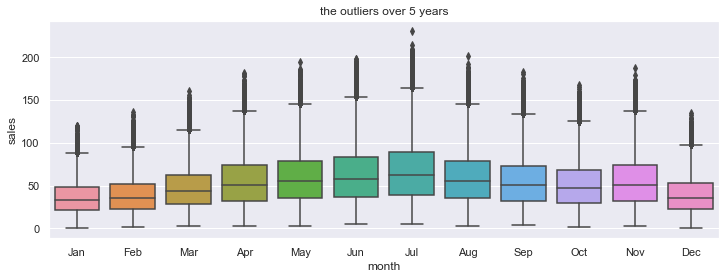

```python
fig, ax = plt.subplots()
fig.set_size_inches((12,4))
sns.boxplot(x='month',y='sales',data=df,ax=ax)
ax.set_title('the outliers over 5 years')
plt.show()
```

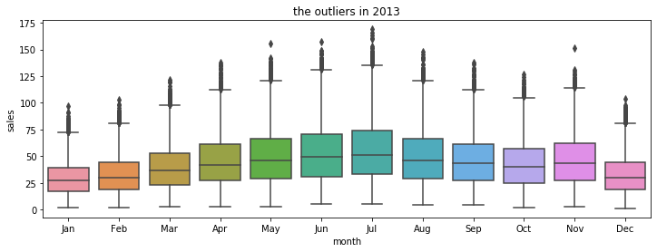

```python
fig, ax = plt.subplots()
fig.set_size_inches((12,4))
sns.boxplot(x='month',y='sales',data=year13,ax=ax)
ax.set_title('the outliers in 2013')
plt.show()
```

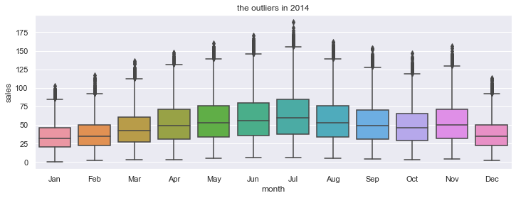

```python
fig, ax = plt.subplots()
fig.set_size_inches((12,4))
sns.boxplot(x='month',y='sales',data=year14,ax=ax)
ax.set_title('the outliers in 2014')
plt.show()
```

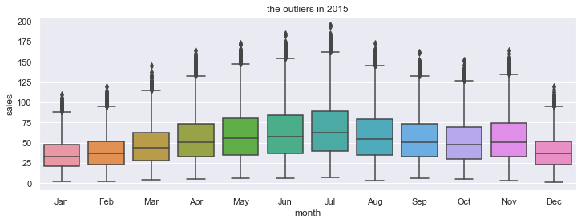

```python
fig, ax = plt.subplots()
fig.set_size_inches((12,4))
sns.boxplot(x='month',y='sales',data=year15,ax=ax)
ax.set_title('the outliers in 2015')
plt.show()
```

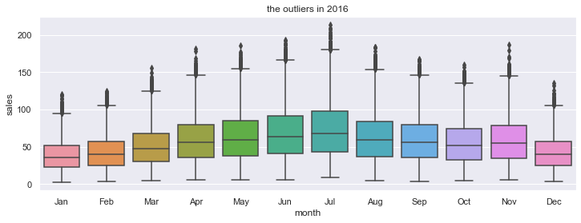

```python
fig, ax = plt.subplots()
fig.set_size_inches((12,4))
sns.boxplot(x='month',y='sales',data=year16,ax=ax)
ax.set_title('the outliers in 2016')
plt.show()
```

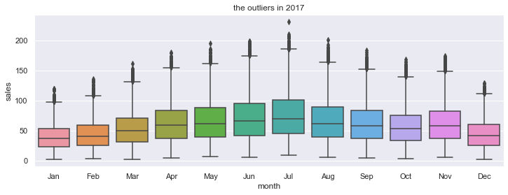

```python
fig, ax = plt.subplots()
fig.set_size_inches((12,4))
sns.boxplot(x='month',y='sales',data=year17,ax=ax )
ax.set_title('the outliers in 2017')
plt.show()
```

The diagram below is helping in identifying the outliers over the 5 years by using boxplot.

```python
dy=df.groupby(df['year'])['sales'].sum()
dy
```

```
year
2013     7941243
2014     9135482
2015     9536887
2016    10357160
2017    10733740
Name: sales, dtype: int64
```

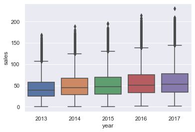

```python
sns.boxplot(x='year', y='sales', data=df)
```

```python
year13['sales'].count()
```

```
182500
```

```python
Q1 = year13['sales'].quantile(0.25)
Q3 = year13['sales'].quantile(0.75)
IQR = Q3 - Q1
trueList = ~((year13['sales'] < (Q1 - 1.5 * IQR)) &(year13['sales'] > (Q3 + 1.5 * IQR)))

trueList.describe()
```

```
count     182500
unique         1
top         True
freq      182500
Name: sales, dtype: object
```